# Reproducible Research Project2 - Weather Events that is harmful to our community

Thomas Jo

2021 5 11

## **Synopsis**

This research tries to find out which severe weather events cause enormous damage to our community. Exploring the U.S National Oceanic and Atmospheric Administration’s(NOAA) storm database can give us the answer to what we’re looking for. We can find out estimates of any fatalities, injuries, and property damage through this database.

## **Data Processing**

**1. DATA**

The data for this assignment come in the form of comma=separated-value file compressed via the bzip2 algorithm to reduce its size.

- [Storm Data](https://d396qusza40orc.cloudfront.net/repdata%2Fdata%2FStormData.csv.bz2)[47mb]

There is also some documentation of the database available. Here you will find how some of the variables are constructed/defined.

- National Weather Service [Storm Data Documentation](https://d396qusza40orc.cloudfront.net/repdata%2Fpeer2_doc%2Fpd01016005curr.pdf)
- National Climatic Data Center Storm Events [FAQ](https://d396qusza40orc.cloudfront.net/repdata%2Fpeer2_doc%2FNCDC%20Storm%20Events-FAQ%20Page.pdf).

The events in the database in the year 1950 and end in November 2011. In the earlier years of the database there are generally fewer events recorded, most likely due to a lack of good records. More recent years should be considered more complete.

**2. Process**

Rather than unzipping the file, I used read.csv to read the file right away. Also, I made a document that stores the data if there’s none

```r
library(dplyr)
```

```r
library(knitr)

if(!file.exists("data")){
  dir.create("data")
}

fileUrl <- "https://d396qusza40orc.cloudfront.net/repdata%2Fdata%2FStormData.csv.bz2"
download.file(fileUrl,destfile = "./data/storm1.csv.bz2")

dfstorm <- read.csv(("./data/storm1.csv.bz2"), header=TRUE, sep = ",")
```

** Most harmful events in the United States(HEALTH) **

Subsetting the dataset can reduce my time and procedures of editting. So I choose few columns to answer the question from the dataset.

```r
df <- subset(dfstorm,select = c("STATE","EVTYPE","FATALITIES","INJURIES","PROPDMG",
                                "PROPDMGEXP","CROPDMG","CROPDMGEXP"))

## There were strings that don't need

df <- df[1:547363,]

h_storm <- subset(df,select = c("EVTYPE","FATALITIES","INJURIES"))
```

I found out there were sentences in the data set. But those sentences disrupt our analysis so I removed them. To calculate the damage we only need **EVTYPE**, **FATALITIES**, **INJURIES** column. **FATALITIES**, **INJURIES** columns’ class were characters so I changed it to numeric.

There were almost one thousand events in the EVTYPE column. But in the Storm Data document, there were only 48 events defined. I have to look up the data to find out how to minimize one thousand events into 48 events. I used the tolower function to make all the letters into small letters to grep the event easily.

```r
h_storm$FATALITIES <- as.numeric(h_storm$FATALITIES)
h_storm$INJURIES <- as.numeric(h_storm$INJURIES)

h_storm$EVTYPE <- tolower(h_storm$EVTYPE)
```

I put all the events in one record to use for-loop to subset the data.

```r
##Storm Event.

storm_event <- c("astronomical low tide","avalanche","blizzard","coastal flood",
                 "debris flow","dense fog","dense smoke","drought","dust devil","dust storm","excessive heat",
                 "frost/freeze","flash flood","flood","cold wind chill","extreme cold/wind chill",
                 "funnel cloud","freezing fog","hail","heat","heavy snow","high surf","high wind",
                 "marine hail","marine high wind","marine strong wind","marine thunderstorm wind",
                 "hurricane","ice storm", "lake effect snow","lakeshore flood","lightning","marine hail",
                 "rip current","seiche","sleet","storm surge","strong wind","thunderstorm wind","tornado",
                 "tropical depression","tropical storm","tsunami","volcanic ash","waterspout","wildfire",
                 "winter storm","winter weather")
```

I made an empty data frame to store the result of each event.

```r
## making an empty data frame
allresult <- data.frame()

for(i in 1:length(storm_event)){
  storm_grep <- grep(storm_event[i],h_storm$EVTYPE)
  storm_ls <- h_storm[storm_grep,]

  storm_result <- summarise(storm_ls,EVTYPE=storm_event[i],
                            FATALITIES=sum(FATALITIES),
                            INJURIES=sum(INJURIES))
  allresult <- rbind(allresult,storm_result)
}



## making a overall health value.

allresult$HEALTH <- allresult$FATALITIES + allresult$INJURIES
or_allresult <- allresult[order(-allresult$HEALTH),][1:10,]
```

**3. RESULT**

In the barplot, we can find out that **tornado** is the most harmful event that causes health damage in our community.

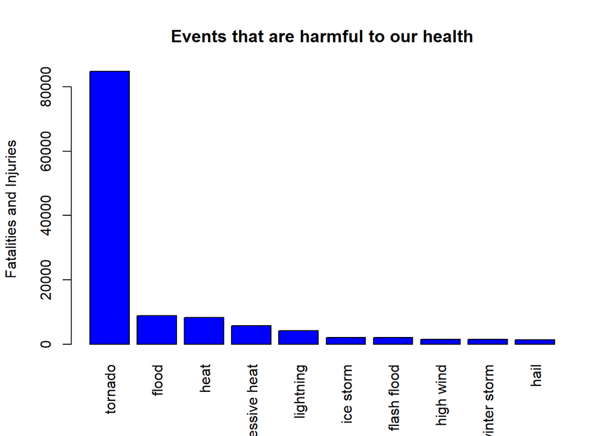

```r
with(or_allresult,barplot(HEALTH,names.arg = EVTYPE,
                       main = "Events that are harmful to our health",col="blue",las=3,
                       ylab="Fatalities and Injuries"))
```

## **Finding which types of events have the greatest economic consequences**

There are two types of damage we have to consider. One is property damage the other is crop damage.

- **Property Damage**

The Dataset also distinguished these two types of damage. We are going to look at the property damage that weather events produce.

I only need three variables in the dataset to figure this out. We know that the data set has thousands of events that are not clear. We are going to take the same steps we’ve done before to make the data tidier. But there are few changes. We have to change **PROPDMGEXP** into numbers that we can easily calculate the actual cost of damage.

```r
prop_df <- df[,c("EVTYPE","PROPDMG","PROPDMGEXP")]

prop_df$EVTYPE <- tolower(prop_df$EVTYPE)

pexp_label <- unique(df$PROPDMGEXP)
pexp_cost <- c(1000,1000000,0,1000000000,1000000,1,10,10,10,0,10,10,10,100,10,100,0,10,10)

prop_table <- data.frame(label = pexp_label, cost = pexp_cost)


## Replacing PROPEMGEXP into numbers that can be calculated.

for(i in 1:nrow(prop_table)){
prop_df$PROPDMGEXP[prop_df$PROPDMGEXP == prop_table[i,1]] <- prop_table[i,2]
}
prop_df$PROPDMG <- as.numeric(prop_df$PROPDMG)
prop_df$PROPDMGEXP <- as.numeric(prop_df$PROPDMGEXP)
prop_df$PROPTOTAL <- prop_df$PROPDMG*prop_df$PROPDMGEXP

##Making an empty data frame.
prop_result <- data.frame()

for(i in 1:length(storm_event)){
  ev_type <- grep(storm_event[i],prop_df$EVTYPE)
  ev_typels <- prop_df[ev_type,]

  ev_result <- summarise(ev_typels,EVTYPE= storm_event[i],
                         PROPTOTAL=sum(PROPTOTAL))

  prop_result <- rbind(prop_result,ev_result)
}
```

- **RESULT**

As a result, we can see that **TORNADO** causes the highest property damage costs in the United States.

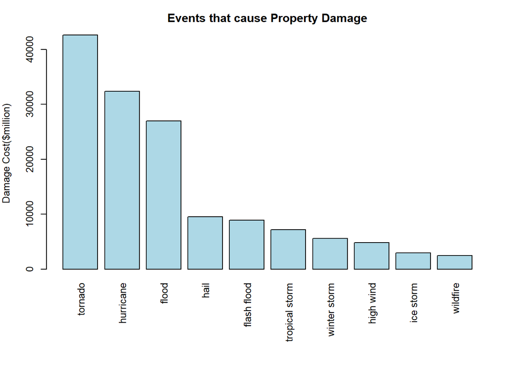

```r
par(mar=c(8,4,3,2),cex=0.8)

or_propdmg <- prop_result[order(-prop_result$PROPTOTAL),][1:10,]

with(or_propdmg,barplot(PROPTOTAL/1000000, names.arg = EVTYPE,
                       main = "Events that cause Property Damage",
                       ylab= "Damage Cost($million)", las=3, col="lightblue"))
```

- **Crop Damage**

We are taking take the same step that we had taken at the top and find out what event damaged the crop most and the cost of the crop damage.

```r
crop_df <- df[,c("EVTYPE","CROPDMG","CROPDMGEXP")]

crop_df$EVTYPE <- tolower(crop_df$EVTYPE)

crop_label <- unique(crop_df$CROPDMGEXP)
crop_cost <- c(0,1000000,1000,1000000,1000000000,0,10,1000,10)

crop_table <- data.frame(label = crop_label,cost = crop_cost)
crop_table$cost <- as.numeric(crop_table$cost)

crop_df$CROPDMGEXP[crop_df$CROPDMGEXP == crop_table[1,1]] <- 0

for(i in 2:nrow(crop_table)){
  crop_df$CROPDMGEXP[crop_df$CROPDMGEXP == crop_table[i,1]] <- crop_table[i,2]
}


## Changing character class into numeric class
crop_df$CROPDMG <- as.numeric(crop_df$CROPDMG)
crop_df$CROPDMGEXP<- as.numeric(crop_df$CROPDMGEXP)

## Getting the exact cost of crop damage.
crop_df$CROPDMGTOTAL <- crop_df$CROPDMG*crop_df$CROPDMGEXP

### Making an empty data frame
crpdmg_result <- data.frame()


for(i in 1:length(storm_event)){
  cp_grep <- grep(storm_event[i],crop_df$EVTYPE)
  cp_ls <- crop_df[cp_grep,]

  cp_result <- summarise(cp_ls,EVTYPE = storm_event[i],
                         CROPDMGTOTAL=sum(CROPDMGTOTAL))
  crpdmg_result<- rbind(crpdmg_result,cp_result)
}
```

- **RESULT**

As a result, we can see that **DROUGHT** causes the highest crop damage costs in the United States.

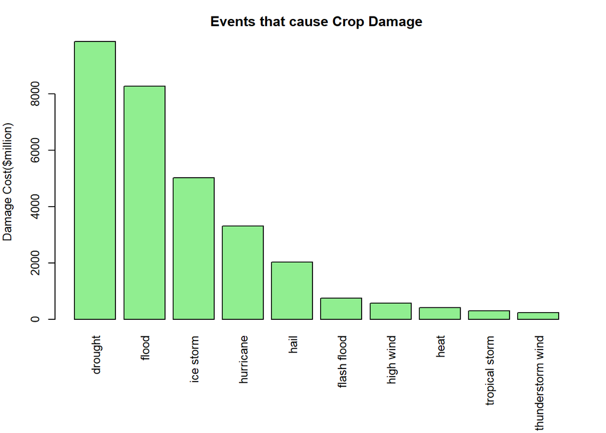

```r
or_crpdmg <- crpdmg_result[order(-crpdmg_result$CROPDMGTOTAL),][1:10,]

par(mar=c(8,4,3,2),cex=0.8)

with(or_crpdmg,barplot(CROPDMGTOTAL/1000000, names.arg = EVTYPE,
                           main = "Events that cause Crop Damage",
                           ylab= "Damage Cost($million)", las=3, col="lightgreen"))
```